# Report 01: Mass-Spectrometry Data Ingestion, Scale Contrast, and Quality Audit

Raw inspection of 12 staged tables across nine human cohorts, sample scale contrast, and provenance traps

Amir Asiaee, Nebojša Jojić, Elizabeth J. Phillips, and Simon A. Mallal

November 22, 2026

Back to Master Index | Next: Report 02 — Core Model & Geometry

# 1 Rationale and Analytical Scope

Before deriving sequence-composition maps or fitting any regression, every staged table from the nine public multimodal cohorts must be audited directly at the observation level. Mass-spectrometry immunopeptidomics exports routinely hide implicit missingness (zero intensities, unmapped accessions, semicolon multi-gene groups), duplicated sample-peptide keys, excluded runs, shared TMT baseline channels, swapped SILAC isotope channel polarity, and multi-date acquisition batches. In this report I load all 12 staged peptide tables plus matched multi-omic metadata, inspect their dimensions and raw structures, contrast two real biological samples side-by-side to ground the numerical scale, verify peptide length (`8–14`-mer) and canonical 20-amino-acid integrity, and lock down our explicit cleaning rules.

# 2 Raw Data Loading, Dimensions, `str()`, and `head()`

### 2.0.1 Rationale

I load every staged peptide table separately before joining or normalizing, recording raw dimensions (`nrow x ncol`), unique biological sample/entry counts versus eluted peptide row counts, unique sequence counts, canonical 9-mer proportions, and column data types.

```python
cohort_specs = [
    ("Stopfer CDK4/6i melanoma", "stopfer/peptides_long.tsv", "\t", "peptide", "signal", "sample_id"),
    ("Newey CRC PDO (2018 replicates)", "newey2019_replicates/peptides_long.tsv.gz", "\t", "peptide", "intensity", "sample_id"),
    ("Newey CRC PDO (2023 synthesis)", "newey2023/peptides_long.tsv.gz", "\t", "peptide", "intensity", "sample_id"),
    ("Velz medulloblastoma (N=28)", "velz2025/peptides_long.tsv.gz", "\t", "peptide", "intensity", "sample_id"),
    ("Bathini MHC1-TIP PDO", "visibility_mhc1tip_gene_unique/pdo/peptides.tsv.gz", "\t", "peptide", "intensity", "sample_id"),
    ("Bathini MHC1-TIP A375", "visibility_mhc1tip_gene_unique/a375/peptides.tsv.gz", "\t", "peptide", "intensity", "sample_id"),
    ("Chong ovarian (UWB1.289)", "visibility_replication/chong2018_gene_unique/peptides.tsv.gz", "\t", "peptide", "intensity", "sample_id"),
    ("Shapiro HAP1 11-KO atlas", "visibility_hap1_gene_unique/peptides.tsv.gz", "\t", "peptide", "normalized_intensity_positive_only", "sample_id"),
    ("Abelin MONTE LUAD (HLA-I)", "visibility_monte/peptides_global_source_strict.tsv.gz", "\t", "peptide", "intensity", "sample_id"),
    ("Abelin MONTE LUAD (HLA-II strict)", "annotations/monte_hlaii_strict.tsv.gz", "\t", "peptide", "intensity", "sample_id"),
    ("Stopfer 2022 MEKi melanoma", "followup/stopfer2022_peptides.tsv.gz", "\t", "peptide", "intensity", "sample_id"),
    ("Bernhardt 2025 pulsed-SILAC", "followup/bernhardt2025_psilac_peptides.tsv.gz", "\t", "peptide", "intensity_total", "sample_id"),
]

inv_rows = []
loaded_meta = {}
for cname, rel, sep, pcol, icol, scol in cohort_specs:
    fp = p_path(*rel.split("/"))
    df = pd.read_csv(fp, sep=sep, low_memory=False)
    peps = df[pcol].astype(str)
    len_s = peps.str.len()
    inv_rows.append({
        "Cohort_Table": cname,
        "Rows": int(len(df)),
        "Cols": int(df.shape[1]),
        "Samples_or_Entries": int(df[scol].nunique()),
        "Unique_Peptides": int(peps.nunique()),
        "Pct_9mers": round(100.0 * float((len_s == 9).mean()), 1),
        "Column_Types": f"{len(df.select_dtypes(include=[np.number]).columns)} num / {len(df.select_dtypes(exclude=[np.number]).columns)} obj",
    })
    loaded_meta[cname] = (df, pcol, icol, scol)

inv_df = pd.DataFrame(inv_rows)
total_obs = int(inv_df["Rows"].sum())

hap1_samples = pd.read_csv(p_path("visibility_hap1_gene_unique", "samples.tsv"), sep="\t")
hap1_samples["hla_genotype"] = hap1_samples["hla_genotype"].astype(str).str.replace("*", "\\*", regex=False)
bern_head = loaded_meta["Bernhardt 2025 pulsed-SILAC"][0].loc[:, [
    "table", "cell_line", "intervention", "time_h", "peptide", "gene", "hla_allele", "l2fc_trt_vs_ref", "ratio_reliable"
]].head(10).copy()
bern_head["hla_allele"] = bern_head["hla_allele"].astype(str).str.replace("*", "\\*", regex=False)
```

```r
# Print R str() on the staged HAP1 sample metadata and Bernhardt SILAC head
str(py$hap1_samples)
```

```
## 'data.frame':    72 obs. of  10 variables:
##  $ sample_id       : chr  "HAP1_B2M_KO_BR1_peptide" "HAP1_B2M_KO_BR2_peptide" "HAP1_B2M_KO_BR3_peptide" "HAP1_CALR_KO_BR1_peptide" ...
##  $ modality        : chr  "peptide" "peptide" "peptide" "peptide" ...
##  $ background      : chr  "HAP1" "HAP1" "HAP1" "HAP1" ...
##  $ condition       : chr  "B2M_KO" "B2M_KO" "B2M_KO" "CALR_KO" ...
##  $ replicate       : num  1 2 3 1 2 3 1 2 3 1 ...
##  $ included        : logi  TRUE TRUE TRUE TRUE TRUE TRUE ...
##  $ qc_reason       : chr  "author_sample_workbook_retained" "author_sample_workbook_retained" "author_sample_workbook_retained" "author_sample_workbook_retained" ...
##  $ n_technical_runs: num  2 2 2 2 2 2 2 2 2 2 ...
##  $ run_dates       : num  20201218 20201218 20201218 20201202 20201202 ...
##  $ hla_genotype    : chr  "HLA-A\\*02:01;HLA-B\\*40:01;HLA-C\\*03:04" "HLA-A\\*02:01;HLA-B\\*40:01;HLA-C\\*03:04" "HLA-A\\*02:01;HLA-B\\*40:01;HLA-C\\*03:04" "HLA-A\\*02:01;HLA-B\\*40:01;HLA-C\\*03:04" ...
##  - attr(*, "pandas.index")=RangeIndex(start=0, stop=72, step=1)
```

```r
str(py$bern_head)
```

```
## 'data.frame':    10 obs. of  9 variables:
##  $ table          : chr  "Table10" "Table10" "Table10" "Table10" ...
##  $ cell_line      : chr  "SKMel28_wt" "SKMel28_wt" "SKMel28_wt" "SKMel28_wt" ...
##  $ intervention   : chr  "VemuCobi" "VemuCobi" "VemuCobi" "VemuCobi" ...
##  $ time_h         : num  24 24 24 24 24 24 24 24 24 24
##  $ peptide        : chr  "AAAAATMAL" "AAAAFVVPR" "AAAAGPRAL" "AAAAKVPAK" ...
##  $ gene           : chr  "INCENP" "FNDC3A" "DR1" "RPL14" ...
##  $ hla_allele     : chr  "HLA-C\\*03:03" "HLA-A\\*11:01" "HLA-C\\*03:03" "HLA-A\\*11:01" ...
##  $ l2fc_trt_vs_ref: num  -0.144 -0.159 0.259 0.116 NaN ...
##  $ ratio_reliable : num  1 0 1 0 0 0 0 0 1 0
##  - attr(*, "pandas.index")=RangeIndex(start=0, stop=10, step=1)
```

```r
show_tbl(py$inv_df, caption = "Table 1.1: Raw inventory across all 12 staged peptide tables (dimensions, sample/entry units, unique peptides, and 9-mer shares).")
```

Table 1.1: Raw inventory across all 12 staged peptide tables (dimensions, sample/entry units, unique peptides, and 9-mer shares).

| Cohort_Table | Rows | Cols | Samples_or_Entries | Unique_Peptides | Pct_9mers | Column_Types |
| --- | --- | --- | --- | --- | --- | --- |
| Stopfer CDK4/6i melanoma | 52338 | 13 | 48 | 5466 | 70.3 | 4 num / 9 obj |
| Newey CRC PDO (2018 replicates) | 512594 | 13 | 44 | 50571 | 56.9 | 6 num / 7 obj |
| Newey CRC PDO (2023 synthesis) | 72512 | 10 | 6 | 34283 | 58.7 | 3 num / 7 obj |
| Velz medulloblastoma (N=28) | 62944 | 9 | 28 | 32199 | 71.1 | 5 num / 4 obj |
| Bathini MHC1-TIP PDO | 33941 | 10 | 18 | 6240 | 48.7 | 3 num / 7 obj |
| Bathini MHC1-TIP A375 | 11164 | 7 | 5 | 2889 | 70.7 | 3 num / 4 obj |
| Chong ovarian (UWB1.289) | 31821 | 12 | 8 | 5771 | 51.8 | 4 num / 8 obj |
| Shapiro HAP1 11-KO atlas | 264731 | 27 | 36 | 18127 | 69.7 | 16 num / 11 obj |
| Abelin MONTE LUAD (HLA-I) | 64584 | 19 | 10 | 44704 | 64.7 | 7 num / 12 obj |
| Abelin MONTE LUAD (HLA-II strict) | 24595 | 9 | 10 | 16508 | 0.0 | 3 num / 6 obj |
| Stopfer 2022 MEKi melanoma | 319406 | 13 | 143 | 18283 | 68.7 | 4 num / 9 obj |
| Bernhardt 2025 pulsed-SILAC | 85411 | 20 | 28 | 16589 | 65.2 | 11 num / 9 obj |

```r
show_tbl(head(py$hap1_samples, 12), caption = "Table 1.2: First 12 rows of Shapiro HAP1 CRISPR sample metadata (run dates, biological replicates, and inclusion flags).")
```

Table 1.2: First 12 rows of Shapiro HAP1 CRISPR sample metadata (run dates, biological replicates, and inclusion flags).

| sample_id | modality | background | condition | replicate | included | qc_reason | n_technical_runs | run_dates | hla_genotype |
| --- | --- | --- | --- | --- | --- | --- | --- | --- | --- |
| HAP1_B2M_KO_BR1_peptide | peptide | HAP1 | B2M_KO | 1 | TRUE | author_sample_workbook_retained | 2 | 20201218 | HLA-A*02:01;HLA-B*40:01;HLA-C*03:04 |
| HAP1_B2M_KO_BR2_peptide | peptide | HAP1 | B2M_KO | 2 | TRUE | author_sample_workbook_retained | 2 | 20201218 | HLA-A*02:01;HLA-B*40:01;HLA-C*03:04 |
| HAP1_B2M_KO_BR3_peptide | peptide | HAP1 | B2M_KO | 3 | TRUE | author_sample_workbook_retained | 2 | 20201218 | HLA-A*02:01;HLA-B*40:01;HLA-C*03:04 |
| HAP1_CALR_KO_BR1_peptide | peptide | HAP1 | CALR_KO | 1 | TRUE | author_sample_workbook_retained | 2 | 20201202 | HLA-A*02:01;HLA-B*40:01;HLA-C*03:04 |
| HAP1_CALR_KO_BR2_peptide | peptide | HAP1 | CALR_KO | 2 | TRUE | author_sample_workbook_retained | 2 | 20201202 | HLA-A*02:01;HLA-B*40:01;HLA-C*03:04 |
| HAP1_CALR_KO_BR3_peptide | peptide | HAP1 | CALR_KO | 3 | TRUE | author_sample_workbook_retained | 2 | 20201202 | HLA-A*02:01;HLA-B*40:01;HLA-C*03:04 |
| HAP1_CANX_KO_BR1_peptide | peptide | HAP1 | CANX_KO | 1 | TRUE | author_sample_workbook_retained | 2 | 20201204 | HLA-A*02:01;HLA-B*40:01;HLA-C*03:04 |
| HAP1_CANX_KO_BR2_peptide | peptide | HAP1 | CANX_KO | 2 | TRUE | author_sample_workbook_retained | 2 | 20201204 | HLA-A*02:01;HLA-B*40:01;HLA-C*03:04 |
| HAP1_CANX_KO_BR3_peptide | peptide | HAP1 | CANX_KO | 3 | TRUE | author_sample_workbook_retained | 2 | 20201204 | HLA-A*02:01;HLA-B*40:01;HLA-C*03:04 |
| HAP1_ERAP1_KO_BR1_peptide | peptide | HAP1 | ERAP1_KO | 1 | TRUE | author_sample_workbook_retained | 2 | 20201211 | HLA-A*02:01;HLA-B*40:01;HLA-C*03:04 |
| HAP1_ERAP1_KO_BR2_peptide | peptide | HAP1 | ERAP1_KO | 2 | TRUE | author_sample_workbook_retained | 2 | 20201211 | HLA-A*02:01;HLA-B*40:01;HLA-C*03:04 |
| HAP1_ERAP1_KO_BR3_peptide | peptide | HAP1 | ERAP1_KO | 3 | TRUE | author_sample_workbook_retained | 2 | 20201211 | HLA-A*02:01;HLA-B*40:01;HLA-C*03:04 |

```r
show_tbl(py$bern_head, digits = 3, caption = "Table 1.3: First 10 rows of the staged Bernhardt 2025 pulsed-SILAC HLA-I peptide table.")
```

Table 1.3: First 10 rows of the staged Bernhardt 2025 pulsed-SILAC HLA-I peptide table.

| table | cell_line | intervention | time_h | peptide | gene | hla_allele | l2fc_trt_vs_ref | ratio_reliable |
| --- | --- | --- | --- | --- | --- | --- | --- | --- |
| Table10 | SKMel28_wt | VemuCobi | 24 | AAAAATMAL | INCENP | HLA-C*03:03 | -0.144 | 1 |
| Table10 | SKMel28_wt | VemuCobi | 24 | AAAAFVVPR | FNDC3A | HLA-A*11:01 | -0.159 | 0 |
| Table10 | SKMel28_wt | VemuCobi | 24 | AAAAGPRAL | DR1 | HLA-C*03:03 | 0.259 | 1 |
| Table10 | SKMel28_wt | VemuCobi | 24 | AAAAKVPAK | RPL14 | HLA-A*11:01 | 0.116 | 0 |
| Table10 | SKMel28_wt | VemuCobi | 24 | AAAAVGPAM | ASCC2 | HLA-C*03:03 | NaN | 0 |
| Table10 | SKMel28_wt | VemuCobi | 24 | AAAGSGAEF | SLC27A3 | HLA-C*03:03 | NaN | 0 |
| Table10 | SKMel28_wt | VemuCobi | 24 | AAAKVLLKK | CENPW | HLA-A*11:01 | NaN | 0 |
| Table10 | SKMel28_wt | VemuCobi | 24 | AAANPTLAF | PUM2 | HLA-C*03:03 | -0.022 | 0 |
| Table10 | SKMel28_wt | VemuCobi | 24 | AAAPPAPFRL | TNFRSF12A | HLA-C*03:03 | 0.052 | 1 |
| Table10 | SKMel28_wt | VemuCobi | 24 | AAAPPLTL | BBC3 | HLA-C*03:03 | -0.817 | 0 |

**What do we see?**

Across the 12 staged peptide tables (Table 1.1), the combined deposit totals **1,536,041** rows ranging from `11,164` (`Bathini MHC1-TIP A375`, `7` columns) to `512,594` (`Newey CRC PDO 2018 replicates`, `13` columns) and `319,406` (`Stopfer 2022 MEKi melanoma`, `13` columns), with biological sample/entry counts spanning `5` (`A375`) to `143` (`Stopfer 2022`). Across the 11 HLA class I tables, canonical `9`-mers make up `48.7%` (`Bathini PDO`) to `71.1%` (`Velz medulloblastoma`) of eluted entries, whereas the `Abelin MONTE HLA-II strict` negative-control table (`24,595` rows across `10` tumors) contains `0.0%` `9`-mers because class II ligands span longer nested cores. R `str()` and `head()` (Tables 1.2–1.3) confirm typed fields in `HAP1` (`72` samples across two modalities, explicit `run_dates` integers like `20201218` and `20201211`, semicolon-delimited four-digit genotypes `HLA-A*02:01;HLA-B*40:01;HLA-C*03:04`) and in `Bernhardt 2025` (`l2fc_trt_vs_ref`, binary `ratio_reliable`, and per-peptide allele annotations).

# 3 Two Real Samples for Scale

### 3.0.1 Rationale

Summary averages across 1.54 million observations hide how drastically individual biological samples differ in depth, length balance, and HLA binding motifs. Following the empirical scale-contrast approach of Coombes and Bombina, I compare two pairs of concrete individual samples side-by-side: (1) two isogenic `HAP1` biological replicates (`HAP1_control_BR1_peptide` vs. `HAP1_TAP2_KO_BR1_peptide`, plus `HAP1_ERAP1_KO_BR1_peptide` for length shift), and (2) two individual melanoma pulsed-SILAC samples from completely disjoint HLA backgrounds (`Ma-Mel-63a` 24 h IFN-$\gamma$ vs. `SK-Mel-28 wt` 72 h vemurafenib + cobimetinib).

```python
# Contrast 1: Real HAP1 biological replicate samples
hp_df = loaded_meta["Shapiro HAP1 11-KO atlas"][0]
hap_eg_ids = ["HAP1_control_BR1_peptide", "HAP1_ERAP1_KO_BR1_peptide", "HAP1_TAP2_KO_BR1_peptide"]
hap_scale_rows = []
for sid in hap_eg_ids:
    sub = hp_df[hp_df["sample_id"] == sid].copy()
    lens = sub["peptide"].astype(str).str.len()
    hap_scale_rows.append({
        "Sample_ID": sid,
        "Unique_Peptides": int(sub["peptide"].nunique()),
        "Total_Norm_Intensity": f"{sub['normalized_intensity_positive_only'].sum():.2e}",
        "Median_Intensity": round(float(sub["normalized_intensity_positive_only"].median()), 1),
        "Pct_8mer": round(100.0 * float((lens == 8).mean()), 1),
        "Pct_9mer": round(100.0 * float((lens == 9).mean()), 1),
        "Pct_10_11mer": round(100.0 * float(lens.isin([10, 11]).mean()), 1),
        "Top_Peptide": str(sub.sort_values("normalized_intensity_positive_only", ascending=False)["peptide"].iloc[0]),
    })
hap_scale_df = pd.DataFrame(hap_scale_rows)

# Contrast 2: Two real Bathini/Chong IFN-gamma biological replicates + Bernhardt zero-HLA-overlap runs
pdo_df = loaded_meta["Bathini MHC1-TIP PDO"][0]
ch_df  = loaded_meta["Chong ovarian (UWB1.289)"][0]
bp_df  = loaded_meta["Bernhardt 2025 pulsed-SILAC"][0]

bio_eg_rows = []
for tag, sub, pcol, icol in [
    ("ITO58M_IFNg_rep1 (CRC PDO)", pdo_df[pdo_df["sample_id"] == "mhc1tip_peptide_ITO58M_IFNG_1"], "peptide", "intensity"),
    ("UWB1.289_IFNg_rep1 (OvCa)", ch_df[ch_df["sample_id"] == "chong2018_peptide_IFNG_1"], "peptide", "intensity"),
]:
    lens = sub[pcol].astype(str).str.len()
    bio_eg_rows.append({
        "Sample": tag,
        "Unique_Peptides": int(sub[pcol].nunique()),
        "Median_Log2_Intensity": round(float(np.log2(sub[icol].replace(0, np.nan).dropna()).median()), 2),
        "Pct_9mer": round(100.0 * float((lens == 9).mean()), 1),
        "P2_Leu_Pct": round(100.0 * float((sub.loc[lens == 9, pcol].str[1] == "L").mean()), 1),
        "P9_Lys_Pct": round(100.0 * float((sub.loc[lens == 9, pcol].str[8] == "K").mean()), 1),
    })

for tag, cond_df in [
    ("MaMel63a IFNg 24h (Table 4)", bp_df[(bp_df["table"] == "Table4") & (bp_df["time_h"] == 24)]),
    ("SKMel28_wt VemuCobi 72h (Table 10)", bp_df[(bp_df["table"] == "Table10") & (bp_df["time_h"] == 72)]),
]:
    d = cond_df.drop_duplicates("peptide")
    lens = d["peptide"].astype(str).str.len()
    d9 = d[lens == 9]
    bio_eg_rows.append({
        "Sample": tag,
        "Unique_Peptides": int(len(d)),
        "Median_Log2_Intensity": round(float(np.log2(d["intensity_total"].replace(0, np.nan).dropna()).median()), 2),
        "Pct_9mer": round(100.0 * float((lens == 9).mean()), 1),
        "P2_Leu_Pct": round(100.0 * float((d9["peptide"].str[1] == "L").mean()), 1),
        "P9_Lys_Pct": round(100.0 * float((d9["peptide"].str[8] == "K").mean()), 1),
    })
bio_scale_df = pd.DataFrame(bio_eg_rows)
```

```r
show_tbl(py$hap_scale_df, caption = "Table 1.4: Real individual biological samples contrasted for scale in HAP1 (Wild-Type vs. ERAP1 KO vs. TAP2 KO).")
```

Table 1.4: Real individual biological samples contrasted for scale in HAP1 (Wild-Type vs. ERAP1 KO vs. TAP2 KO).

| Sample_ID | Unique_Peptides | Total_Norm_Intensity | Median_Intensity | Pct_8mer | Pct_9mer | Pct_10_11mer | Top_Peptide |
| --- | --- | --- | --- | --- | --- | --- | --- |
| HAP1_control_BR1_peptide | 15716 | 9.36e+09 | 104531.5 | 5.5 | 66.8 | 27.7 | GEVDPKVAL |
| HAP1_ERAP1_KO_BR1_peptide | 6694 | 7.14e+09 | 203235.5 | 4.0 | 61.4 | 34.7 | SIYPSPTGV |
| HAP1_TAP2_KO_BR1_peptide | 2090 | 2.40e+10 | 169969.5 | 12.7 | 66.8 | 20.5 | LLLPGPSAA |

```r
show_tbl(py$bio_scale_df, caption = "Table 1.5: Real organoid/ovarian IFN-gamma replicates and zero-HLA-overlap melanoma pSILAC runs contrasted side-by-side.")
```

Table 1.5: Real organoid/ovarian IFN-gamma replicates and zero-HLA-overlap melanoma pSILAC runs contrasted side-by-side.

| Sample | Unique_Peptides | Median_Log2_Intensity | Pct_9mer | P2_Leu_Pct | P9_Lys_Pct |
| --- | --- | --- | --- | --- | --- |
| ITO58M_IFNg_rep1 (CRC PDO) | 2316 | 19.71 | 56.1 | 23.2 | 1.6 |
| UWB1.289_IFNg_rep1 (OvCa) | 4396 | 25.09 | 49.0 | 12.5 | 28.6 |
| MaMel63a IFNg 24h (Table 4) | 4984 | 23.79 | 69.1 | 44.1 | 25.1 |
| SKMel28_wt VemuCobi 72h (Table 10) | 3223 | 23.08 | 63.8 | 13.4 | 70.4 |

**What do we see?**

Contrasting concrete individual runs side-by-side makes the dynamic range of raw immunopeptidomes immediately concrete (Tables 1.4–1.5):

- **Isogenic `HAP1` biological replicates:** Wild-type `HAP1_control_BR1_peptide` yields `15,716` unique peptides (`9.36e+09` total normalized intensity, median `104,531.5`), dominated by `66.8%` `9`-mers and `27.7%` `10–11`-mers (`5.5%` `8`-mers; top ligand `GEVDPKVAL`). Deleting *ERAP1* (`HAP1_ERAP1_KO_BR1_peptide`) halves observed breadth (`6,694` peptides) while shifting length upward toward untrimmed `10–11`-mers (`34.7%`; top ligand `SIYPSPTGV`). Deleting *TAP2* (`HAP1_TAP2_KO_BR1_peptide`) collapses breadth by `86.7%` (`2,090` peptides), doubles `8`-mer share to `12.7%`, and leaves the repertoire topped by the N-terminal leader peptide `LLLPGPSAA` (`2.40e+10` summed signal among surviving entries).
- **Primary organoid, ovarian, and melanoma runs:** Individual `ITO58M_IFNg_rep1` (`2,316` peptides, median $\log_2$ intensity `19.71`) shows `23.2%` P2-Leu vs. `1.6%` P9-Lys, whereas ovarian `UWB1.289_IFNg_rep1` (`4,396` peptides, median `25.09`) carries `28.6%` P9-Lys. In pulsed-SILAC melanoma, `MaMel63a IFNg 24h` (`4,984` peptides) is strongly P2-Leu enriched (`44.1%` P2-Leu vs. `25.1%` P9-Lys), whereas `SKMel28_wt VemuCobi 72h` (`3,223` peptides) shifts sharply to `70.4%` P9-Lys with only `13.4%` P2-Leu.

# 4 Completeness, Missingness, Peptide Length, and Contaminant QC

### 4.0.1 Rationale

I audit explicit `NA` counts, implicit zero or non-positive signals, empty or `"UNMAPPED"` gene names, semicolon-delimited multi-gene strings (`GENE1;GENE2`), non-canonical amino-acid characters outside the 20 standard residues, and exact duplicate `(sample_id, peptide)` keys across all 12 tables, plus column-level missingness in the integrated `Stopfer 2022` `SKMEL5` multi-omics table.

```python
miss_rows = []
dup_rows = []
for cname, (df, pcol, icol, scol) in loaded_meta.items():
    n_rows = len(df)
    na_int = int(df[icol].isna().sum()) if icol in df.columns else 0
    num_vals = pd.to_numeric(df[icol], errors="coerce") if icol in df.columns else pd.Series(dtype=float)
    zero_or_neg = int((num_vals <= 0).sum())
    gcol = "gene" if "gene" in df.columns else None
    na_gene = int(df[gcol].isna().sum()) if gcol else n_rows
    empty_gene = int((df[gcol].astype(str).str.strip().isin(["", "nan", "None", "UNMAPPED"])).sum()) if gcol else 0
    ambig_gene = int(df[gcol].astype(str).str.contains(";").sum()) if gcol else 0
    peps = df[pcol].astype(str)
    noncanonical_aa = int((~peps.map(lambda s: set(s) <= set(AMINO_ACIDS))).sum())
    out_8_14 = int((~peps.str.len().between(8, 14)).sum())
    complete_req = int(df[[c for c in (pcol, icol, gcol) if c is not None]].dropna().shape[0])
    miss_rows.append({
        "Cohort_Table": cname,
        "Rows": n_rows,
        "Explicit_NA_Int": na_int,
        "Zero_NonPos": zero_or_neg,
        "Empty_Unmapped_Gene": empty_gene,
        "MultiGene_Semicolon": ambig_gene,
        "NonCanonical_AA": noncanonical_aa,
        "Outside_8_14mer": out_8_14,
        "Complete_Pct": round(100.0 * complete_req / max(n_rows, 1), 1),
    })
    dup_rows.append({
        "Cohort_Table": cname,
        "Exact_Row_Dups": int(df.duplicated().sum()),
        "Dup_Sample_Peptide_Keys": int(df.duplicated(subset=[scol, pcol]).sum()),
    })

miss_df = pd.DataFrame(miss_rows)
dup_df = pd.DataFrame(dup_rows)

sk5_om = pd.read_csv(p_path("followup", "stopfer2022_skmel5_multiomics.tsv.gz"), sep="\t")
sk5_na = pd.DataFrame({
    "Column": sk5_om.columns,
    "Dtype": [str(t) for t in sk5_om.dtypes],
    "Explicit_NA": [int(sk5_om[c].isna().sum()) for c in sk5_om.columns],
    "Pct_Missing": [round(100.0 * sk5_om[c].isna().mean(), 1) for c in sk5_om.columns],
})
```

```r
show_tbl(py$miss_df, caption = "Table 1.6: Missingness, gene-mapping ambiguity, sequence alphabet, and 8-14-mer length integrity across all 12 staged tables.")
```

Table 1.6: Missingness, gene-mapping ambiguity, sequence alphabet, and 8-14-mer length integrity across all 12 staged tables.

| Cohort_Table | Rows | Explicit_NA_Int | Zero_NonPos | Empty_Unmapped_Gene | MultiGene_Semicolon | NonCanonical_AA | Outside_8_14mer | Complete_Pct |
| --- | --- | --- | --- | --- | --- | --- | --- | --- |
| Stopfer CDK4/6i melanoma | 52338 | 0 | 0 | 0 | 0 | 0 | 270 | 100.0 |
| Newey CRC PDO (2018 replicates) | 512594 | 0 | 0 | 691 | 36313 | 0 | 4481 | 99.9 |
| Newey CRC PDO (2023 synthesis) | 72512 | 8971 | 0 | 0 | 0 | 0 | 964 | 87.6 |
| Velz medulloblastoma (N=28) | 62944 | 0 | 1888 | 0 | 0 | 0 | 0 | 100.0 |
| Bathini MHC1-TIP PDO | 33941 | 0 | 0 | 0 | 0 | 0 | 0 | 100.0 |
| Bathini MHC1-TIP A375 | 11164 | 0 | 0 | 0 | 0 | 0 | 0 | 100.0 |
| Chong ovarian (UWB1.289) | 31821 | 0 | 0 | 0 | 0 | 0 | 0 | 100.0 |
| Shapiro HAP1 11-KO atlas | 264731 | 0 | 0 | 0 | 0 | 0 | 0 | 100.0 |
| Abelin MONTE LUAD (HLA-I) | 64584 | 0 | 0 | 0 | 0 | 0 | 0 | 100.0 |
| Abelin MONTE LUAD (HLA-II strict) | 24595 | 0 | 0 | 0 | 0 | 0 | 15897 | 100.0 |
| Stopfer 2022 MEKi melanoma | 319406 | 0 | 0 | 18 | 0 | 0 | 1781 | 100.0 |
| Bernhardt 2025 pulsed-SILAC | 85411 | 0 | 5979 | 129 | 0 | 0 | 200 | 99.8 |

```r
show_tbl(py$dup_df, caption = "Table 1.7: Exact row duplicates and duplicate (sample_id, peptide) keys.")
```

Table 1.7: Exact row duplicates and duplicate (sample_id, peptide) keys.

| Cohort_Table | Exact_Row_Dups | Dup_Sample_Peptide_Keys |
| --- | --- | --- |
| Stopfer CDK4/6i melanoma | 0 | 0 |
| Newey CRC PDO (2018 replicates) | 0 | 0 |
| Newey CRC PDO (2023 synthesis) | 0 | 0 |
| Velz medulloblastoma (N=28) | 0 | 0 |
| Bathini MHC1-TIP PDO | 0 | 0 |
| Bathini MHC1-TIP A375 | 0 | 0 |
| Chong ovarian (UWB1.289) | 0 | 0 |
| Shapiro HAP1 11-KO atlas | 0 | 0 |
| Abelin MONTE LUAD (HLA-I) | 0 | 0 |
| Abelin MONTE LUAD (HLA-II strict) | 0 | 0 |
| Stopfer 2022 MEKi melanoma | 0 | 0 |
| Bernhardt 2025 pulsed-SILAC | 0 | 0 |

```r
show_tbl(py$sk5_na, caption = "Table 1.8: Column-level missingness in the Stopfer 2022 SKMEL5 multi-omics matrix.")
```

Table 1.8: Column-level missingness in the Stopfer 2022 SKMEL5 multi-omics matrix.

| Column | Dtype | Explicit_NA | Pct_Missing |
| --- | --- | --- | --- |
| gene | object | 0 | 0.0 |
| rna_l2fc_100nM | float64 | 87 | 0.5 |
| rna_l2fc_1uM | float64 | 87 | 0.5 |
| rna_padj_100nM | float64 | 87 | 0.5 |
| rna_padj_1uM | float64 | 87 | 0.5 |
| prot_dmso_l2 | float64 | 11875 | 69.6 |
| prot_meki100nM_l2 | float64 | 11875 | 69.6 |
| prot_l2fc_100nM | float64 | 11875 | 69.6 |
| prot_se_100nM | float64 | 11875 | 69.6 |
| ub_l2fc_100nM | float64 | 16355 | 95.9 |
| ub_sites | float64 | 16355 | 95.9 |

**What do we see?**

Tables 1.6–1.8 quantify exact sequence hygiene and cohort-specific missingness before any filtering:

- **Sequence alphabet & duplication:** Across all `1,536,041` staged rows, there are `0` non-canonical amino-acid characters (`NonCanonical_AA = 0` everywhere), `0` exact duplicate rows, and `0` duplicate `(sample_id, peptide)` keys. Class I peptide lengths outside `8–14` residues remain rare (`0.0%–1.3%`; e.g., `270 / 52,338` in `Stopfer 2020`, `1,781 / 319,406` in `Stopfer 2022`), whereas `Abelin MONTE HLA-II strict` naturally sits outside `8–14`-mers (`15,897 / 24,595` longer class II ligands).
- **Gene ambiguity & explicit/zero missingness:** `Newey 2018` carries `36,313` semicolon multi-gene groups and `691` empty/unmapped gene strings; `Newey 2023` reports `8,971` explicit `NA` intensities (`87.6%` completeness); `Velz 2025` contains `1,888` zero intensities; and `Bernhardt 2025` contains `5,979` zero total-intensity entries plus `129` unmapped gene labels (`99.8%` key completeness). In `Stopfer 2022 SKMEL5` (`17,058` genes, Table 1.8), RNA-seq has only `87` (`0.5%`) NAs, whereas whole proteome (`11,875` NAs, `69.6%`) and ubiquitylation (`16,355` NAs, `95.9%`) cover narrower subsets requiring explicit non-missing filtering per regression.

# 5 Structural Cohort Traps and Donor Anchor Geometry

### 5.0.1 Rationale

Beyond missing values and duplicates, six structural data traps were uncovered during provenance auditing of the original deposits: (1) an outlier control sample in `Bathini A375`; (2) reused DMSO baseline channels across doses in `Stopfer 2020`; (3) acquisition-era confounding (`2017` untreated vs. `2018` treated) in `Newey 2019`; (4) inverted SILAC Medium/Heavy labeling in `Bernhardt Table 4` relative to `Tables 7–11`; (5) run-date separation between `TAP1/2` (`20201127`) and the other nine `HAP1` knockouts; and (6) serial flow-through (`FT`) vs. independent non-depleted (`noIP`) tissue aliquots in `Abelin MONTE`. Furthermore, checking P2 and P9 anchor motifs and four-digit HLA overlap between `Ma-Mel-63a`/`UKE-Mel-105b` and `SK-Mel-28` establishes the zero-HLA-overlap transfer baseline.

```python
qc_rows = []
for tag, pdir in [
    ("Bathini PDO", p_path("visibility_mhc1tip_gene_unique", "pdo")),
    ("Bathini A375", p_path("visibility_mhc1tip_gene_unique", "a375")),
    ("Chong UWB1.289", p_path("visibility_replication", "chong2018_gene_unique")),
    ("Shapiro HAP1", p_path("visibility_hap1_gene_unique")),
]:
    sm = pd.read_csv(pdir / "samples.tsv", sep="\t")
    excl = sm[sm["included"] == False]
    qc_rows.append({
        "Cohort": tag,
        "Total_Samples": int(len(sm)),
        "Included": int((sm["included"] == True).sum()),
        "Excluded": int(len(excl)),
        "Excluded_IDs": ", ".join(excl["sample_id"].astype(str).tolist()) if len(excl) else "None",
        "QC_Reason": "; ".join(excl["qc_reason"].dropna().astype(str).unique().tolist()) if len(excl) and "qc_reason" in excl.columns else "None",
    })
qc_df = pd.DataFrame(qc_rows)

st20_s = pd.read_csv(p_path("stopfer", "samples.tsv"), sep="\t")
st20_reuse = int(st20_s["control_reuse_across_doses"].fillna(False).astype(bool).sum()) if "control_reuse_across_doses" in st20_s.columns else 0
nw_s = pd.read_csv(p_path("newey2019_replicates", "samples.tsv"), sep="\t")
nw_era = nw_s.groupby(["condition", "acquisition_era"]).size().reset_index(name="n_samples")

bern_pol = bp_df[bp_df["experiment_tag"] == "Treat_T1"].groupby(["table", "cell_line", "intervention"]).agg(
    n_peps=("peptide", "count"),
    n_reliable=("ratio_reliable", "sum"),
    median_raw_l2_hm=("norm_l2_hm", "median"),
    median_trt_vs_ref=("l2fc_trt_vs_ref", "median"),
    median_H_pulse=("intensity_H", "median"),
    median_M_pulse=("intensity_M", "median"),
).reset_index()

# Peptide length & anchor distributions
len_rows = []
for cname in ["Bathini MHC1-TIP PDO", "Chong ovarian (UWB1.289)", "Shapiro HAP1 11-KO atlas", "Abelin MONTE LUAD (HLA-I)", "Bernhardt 2025 pulsed-SILAC"]:
    df, pcol, _, _ = loaded_meta[cname]
    d = df.drop_duplicates(pcol).copy()
    L = d[pcol].astype(str).str.len()
    row = {"Cohort": cname, "Unique_Peps": int(len(d))}
    for k in [8, 9, 10, 11, 12]:
        row[f"Pct_{k}mer"] = round(100.0 * float((L == k).mean()), 1)
    row["Pct_ge13mer"] = round(100.0 * float((L >= 13).mean()), 1)
    len_rows.append(row)
len_df = pd.DataFrame(len_rows)

bp9 = bp_df[(bp_df["length"] == 9) & (bp_df["peptide"].map(lambda s: set(str(s)) <= set(AMINO_ACIDS)))].drop_duplicates(["cell_line", "peptide"])
p2_rows = []
for line in ["MaMel63a", "UKEMel105b", "SKMel28_wt", "SKMel28_dr"]:
    sub = bp9[bp9["cell_line"] == line]
    p2_top = sub["peptide"].str[1].value_counts(normalize=True).head(4)
    p9_top = sub["peptide"].str[8].value_counts(normalize=True).head(4)
    p2_rows.append({
        "Cell_Line": line,
        "Unique_9mers": int(len(sub)),
        "Top_P2_Anchors": ", ".join([f"{aa}:{100*v:.1f}%" for aa, v in p2_top.items()]),
        "Top_P9_Anchors": ", ".join([f"{aa}:{100*v:.1f}%" for aa, v in p9_top.items()]),
    })
anchor_df = pd.DataFrame(p2_rows)

b_tr_al = sorted({a for a in bp_df[bp_df["cell_line"].isin(["MaMel63a", "UKEMel105b"])]["hla_allele"].dropna().astype(str) if "*" in a})
b_sk_al = sorted({a for a in bp_df[bp_df["cell_line"].isin(["SKMel28_wt", "SKMel28_dr"])]["hla_allele"].dropna().astype(str) if "*" in a})
b_tr_peps = set(bp9[bp9["cell_line"].isin(["MaMel63a", "UKEMel105b"])]["peptide"])
b_sk_peps = set(bp9[bp9["cell_line"].isin(["SKMel28_wt", "SKMel28_dr"])]["peptide"])
uke_j = json.loads((RES_ROOT / "exp8_immunity_bridge/uke_mel_105b_genotype_and_overlap_audit.json").read_text()) if (RES_ROOT / "exp8_immunity_bridge/uke_mel_105b_genotype_and_overlap_audit.json").exists() else json.loads((RES_ROOT / "salvage/exp8_immunity_bridge/uke_mel_105b_genotype_and_overlap_audit.json").read_text())
c_ov = uke_j["peptide_overlap_reconciliation"]["contrast_eligible_resistance_benchmark_Tables7_11"]
il_ov = uke_j["peptide_overlap_reconciliation"]["isobaric_IL_harmonized_resistance_benchmark"]
hla_overlap_df = pd.DataFrame([{
    "Train_Deposited_Table_HLAs": ", ".join([a.replace("*", "\\*") for a in b_tr_al]),
    "UKEMel105b_Reconciliation": "Paper text B\\*25:01 (0 IMGT records) vs Table 8 B\\*35:01 (400 9-mers)",
    "SKMel28_4Digit_HLAs": ", ".join([a.replace("*", "\\*") for a in b_sk_al]),
    "Shared_4Digit_HLAs": len(set(b_tr_al) & set(b_sk_al)),
    "AllStaged_Shared_9mers": f"{len(b_tr_peps & b_sk_peps)} / {len(b_sk_peps)} (train {len(b_tr_peps)})",
    "ContrastEligible_Shared_9mers": f"{c_ov['shared_9mers']} / {c_ov['skmel28_9mers']} (I=L: {il_ov['shared_unique_IL_9mers']})",
}])

# Cross-modality check in Velz and UniProt topology
topo = pd.read_csv(p_path("annotations", "gene_topology_summary.tsv.gz"), sep="\t")
velz_s = pd.read_csv(p_path("velz2025", "samples.tsv"), sep="\t")
velz_rna = pd.read_csv(p_path("velz2025", "RNA_gene_tpm.tsv.gz"), sep="\t")
velz_pep = loaded_meta["Velz medulloblastoma (N=28)"][0]
velz_align = pd.DataFrame([{
    "Velz_Meta": int(len(velz_s)),
    "Velz_RNA": int(velz_rna["sample_id"].nunique()),
    "Velz_HLA_MS": int(velz_pep["sample_id"].nunique()),
    "Exact_ID_Match": int(len(set(velz_s["sample_id"]) & set(velz_rna["sample_id"]) & set(velz_pep["sample_id"]))),
    "Subgroups": ", ".join([f"{k}:{v}" for k, v in velz_s["molecular_subgroup"].value_counts().items()]),
    "UniProt_Genes": int(len(topo)),
    "Pct_Signal_Peptide": round(100.0 * float(topo["has_signal_peptide"].mean()), 1),
    "Pct_Secretory_ER_Memb": round(100.0 * float(topo["is_secretory_er_membrane"].mean()), 1),
}])
```

```r
show_tbl(py$qc_df, caption = "Table 1.9: Sample inclusion vs. QC exclusion audit across Bathini, Chong, and HAP1.")
```

Table 1.9: Sample inclusion vs. QC exclusion audit across Bathini, Chong, and HAP1.

| Cohort | Total_Samples | Included | Excluded | Excluded_IDs | QC_Reason |
| --- | --- | --- | --- | --- | --- |
| Bathini PDO | 36 | 36 | 0 | None | None |
| Bathini A375 | 12 | 11 | 1 | mhc1tip_peptide_A375_control_2 | All precursor quantities missing/zero; author code exclusion |
| Chong UWB1.289 | 16 | 16 | 0 | None | None |
| Shapiro HAP1 | 72 | 72 | 0 | None | None |

```r
show_tbl(py$nw_era, caption = "Table 1.10: Acquisition-era structure in Newey 2019 colorectal organoids (2017 UT vs 2018 IFNg/TRAM).")
```

Table 1.10: Acquisition-era structure in Newey 2019 colorectal organoids (2017 UT vs 2018 IFNg/TRAM).

| condition | acquisition_era | n_samples |
| --- | --- | --- |
| IFNg | 2018 | 18 |
| TRAM | 2018 | 16 |
| UT | 2017 | 10 |

```r
show_tbl(py$bern_pol, digits = 3, caption = "Table 1.11: Bernhardt 2025 24 h SILAC channel polarity audit showing Table 4 inversion (M=IFNg, H=Ctrl).")
```

Table 1.11: Bernhardt 2025 24 h SILAC channel polarity audit showing Table 4 inversion (M=IFNg, H=Ctrl).

| table | cell_line | intervention | n_peps | n_reliable | median_raw_l2_hm | median_trt_vs_ref | median_H_pulse | median_M_pulse |
| --- | --- | --- | --- | --- | --- | --- | --- | --- |
| Table10 | SKMel28_wt | VemuCobi | 3088 | 1008 | 0.013 | 0.013 | 3682250 | 4141550 |
| Table11 | SKMel28_dr | VemuCobi | 3738 | 970 | 0.004 | 0.004 | 3659100 | 2864060 |
| Table12 | SKMel28_wtVSdr | Resistance_dr_vs_wt | 2688 | 803 | -0.051 | -0.051 | 3452750 | 5058550 |
| Table4 | MaMel63a | IFNg | 3837 | 3635 | -0.445 | 0.445 | 12518000 | 25743000 |
| Table7 | MaMel63a | Trametinib | 3569 | 890 | 0.011 | 0.011 | 2854400 | 4750120 |
| Table8 | UKEMel105b | Trametinib | 3745 | 705 | 0.011 | 0.011 | 5549100 | 5551300 |
| Table9 | MaMel63a | VemuCobi | 3504 | 872 | 0.023 | 0.023 | 4172525 | 5427300 |

```r
show_tbl(py$len_df, caption = "Table 1.12: Peptide length distributions across unique peptides per cohort.")
```

Table 1.12: Peptide length distributions across unique peptides per cohort.

| Cohort | Unique_Peps | Pct_8mer | Pct_9mer | Pct_10mer | Pct_11mer | Pct_12mer | Pct_ge13mer |
| --- | --- | --- | --- | --- | --- | --- | --- |
| Bathini MHC1-TIP PDO | 6240 | 14.3 | 52.3 | 19.7 | 13.7 | 0.0 | 0.0 |
| Chong ovarian (UWB1.289) | 5771 | 0.4 | 52.8 | 28.6 | 18.2 | 0.0 | 0.0 |
| Shapiro HAP1 11-KO atlas | 18127 | 5.7 | 64.8 | 19.2 | 10.2 | 0.0 | 0.0 |
| Abelin MONTE LUAD (HLA-I) | 44704 | 11.6 | 63.2 | 14.4 | 8.0 | 2.8 | 0.0 |
| Bernhardt 2025 pulsed-SILAC | 16589 | 6.4 | 64.8 | 16.2 | 8.4 | 2.1 | 2.2 |

```r
show_tbl(py$anchor_df, caption = "Table 1.13: Top P2 and P9 anchor residues in Bernhardt 2025 melanoma cell lines.")
```

Table 1.13: Top P2 and P9 anchor residues in Bernhardt 2025 melanoma cell lines.

| Cell_Line | Unique_9mers | Top_P2_Anchors | Top_P9_Anchors |
| --- | --- | --- | --- |
| MaMel63a | 6395 | L:48.4%, V:12.0%, P:9.0%, T:7.5% | L:28.9%, K:26.5%, V:19.7%, Y:5.5% |
| UKEMel105b | 2858 | L:38.2%, V:17.3%, T:13.9%, A:7.8% | K:55.6%, Y:15.9%, R:9.9%, F:6.3% |
| SKMel28_wt | 2337 | T:26.3%, V:25.5%, S:15.6%, L:13.5% | K:70.1%, R:15.1%, L:7.6%, Y:2.4% |
| SKMel28_dr | 2774 | T:23.5%, V:22.9%, S:13.7%, L:11.9% | K:62.1%, L:17.4%, R:11.8%, Y:2.5% |

```r
show_tbl(py$hla_overlap_df, caption = "Table 1.14: Zero four-digit HLA allele overlap between Ma-Mel-63a / UKE-Mel-105b training lines and SK-Mel-28.")
```

Table 1.14: Zero four-digit HLA allele overlap between Ma-Mel-63a / UKE-Mel-105b training lines and SK-Mel-28.

| Train_Deposited_Table_HLAs | UKEMel105b_Reconciliation | SKMel28_4Digit_HLAs | Shared_4Digit_HLAs | AllStaged_Shared_9mers | ContrastEligible_Shared_9mers |
| --- | --- | --- | --- | --- | --- |
| HLA-A*02:01, HLA-A*03:01, HLA-B*07:02, HLA-B*18:01, HLA-B*35:01, HLA-C*04:01, HLA-C*06:02 | Paper text B*25:01 (0 IMGT records) vs Table 8 B*35:01 (400 9-mers) | HLA-A*11:01, HLA-B*40:01, HLA-C*03:03 | 0 | 961 / 3490 (train 7909) | 869 / 3167 (I=L: 877) |

```r
show_tbl(py$velz_align, caption = "Table 1.15: Cross-modality alignment in Velz medulloblastomas (N=28) and UniProt human topology coverage.")
```

Table 1.15: Cross-modality alignment in Velz medulloblastomas (N=28) and UniProt human topology coverage.

| Velz_Meta | Velz_RNA | Velz_HLA_MS | Exact_ID_Match | Subgroups | UniProt_Genes | Pct_Signal_Peptide | Pct_Secretory_ER_Memb |
| --- | --- | --- | --- | --- | --- | --- | --- |
| 28 | 28 | 28 | 28 | SHH:9, G4:8, G3:7, WNT:4 | 20188 | 17.8 | 46 |

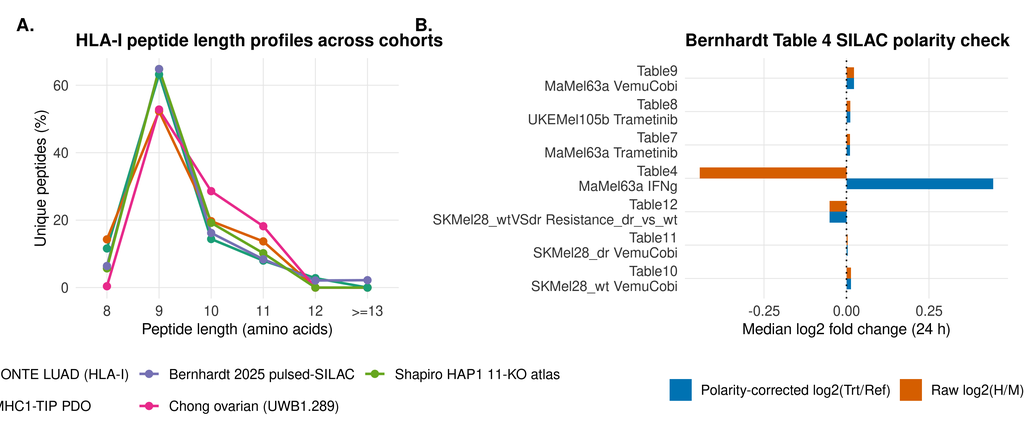

```r
len_long <- py$len_df |>
  select(Cohort, Pct_8mer, Pct_9mer, Pct_10mer, Pct_11mer, Pct_12mer, Pct_ge13mer) |>
  pivot_longer(-Cohort, names_to = "Len", values_to = "Pct") |>
  mutate(Len = recode(Len, Pct_8mer = "8", Pct_9mer = "9", Pct_10mer = "10", Pct_11mer = "11", Pct_12mer = "12", Pct_ge13mer = ">=13"),
         Len = factor(Len, levels = c("8", "9", "10", "11", "12", ">=13")))

p_len <- ggplot(len_long, aes(x = Len, y = Pct, color = Cohort, group = Cohort)) +
  geom_line(linewidth = 0.85) +
  geom_point(size = 2.1) +
  scale_color_brewer(palette = "Dark2") +
  guides(color = guide_legend(nrow = 2)) +
  labs(x = "Peptide length (amino acids)", y = "Unique peptides (%)", color = NULL, title = "HLA-I peptide length profiles across cohorts")

p_pol <- py$bern_pol |>
  mutate(Label = paste0(table, "\n", cell_line, " ", intervention)) |>
  pivot_longer(c(median_raw_l2_hm, median_trt_vs_ref), names_to = "Metric", values_to = "Median_L2FC") |>
  mutate(Metric = recode(Metric, median_raw_l2_hm = "Raw log2(H/M)", median_trt_vs_ref = "Polarity-corrected log2(Trt/Ref)")) |>
  ggplot(aes(x = Label, y = Median_L2FC, fill = Metric)) +
  geom_col(position = "dodge", width = 0.65) +
  geom_hline(yintercept = 0, linetype = "dotted") +
  coord_flip() +
  scale_fill_manual(values = c("Raw log2(H/M)" = ORANGE, "Polarity-corrected log2(Trt/Ref)" = BLUE)) +
  labs(x = NULL, y = "Median log2 fold change (24 h)", fill = NULL, title = "Bernhardt Table 4 SILAC polarity check")

tagged(p_len + p_pol)
```

**What do we see?**

Tables 1.9–1.15 and Figure 1.1 document all six cohort-specific structural traps and donor HLA geometry:

1. **Outlier run exclusion (Table 1.9):** Out of `36` Bathini PDO, `12` Bathini A375, `16` Chong ovarian, and `72` HAP1 runs, exactly one sample fails QC—`mhc1tip_peptide_A375_control_2`—because all precursor intensities are missing/zero in the original author deposit.
2. **Acquisition-era confounding (Table 1.10):** In `Newey 2019`, all `10` untreated runs were acquired in `2017` whereas all `18` IFN-$\gamma$ and `16` trametinib runs were acquired in `2018`; comparing IFN-$\gamma$ against trametinib within `2018` removes this era shift.
3. **SILAC channel inversion (Table 1.11 & Figure 1.1B):** In `Bernhardt 2025`, `Table 4` (`Ma-Mel-63a` IFN-$\gamma$, `n = 3,635` reliable ratios) exhibits median raw $\log_2(\mathrm{H}/\mathrm{M}) = -0.445$ while `H_pulse = 12.52M` vs. `M_pulse = 25.74M`, confirming `M = IFN-gamma` and `H = Control` inverted relative to `Tables 7–11`. Polarity correction restores positive `+0.445`.
4. **Length, genotype reconciliation & anchor divergence (`0` shared 4-digit HLAs, Tables 1.12–1.14 & Figure 1.1A):** Canonical `9`-mers account for `52.3%` (`Bathini PDO`) to `64.8%` (`HAP1` and `Bernhardt`) of unique peptides across cohorts. Across cell lines, `Ma-Mel-63a` (`6,395` `9`-mers) is anchored by `P2 = Leu` (`48.4%`) whereas `SK-Mel-28 wt` (`2,337`) and `dr` (`2,774`) switch to `P2 = Thr/Val` (`26.3%/25.5%`) and `P9 = Lys` (`70.1%/62.1%`). For `UKE-Mel-105b`, Bernhardt et al.’s prose prints `HLA-B*25:01` (`0` records in IPD-IMGT/HLA), whereas deposited `Table 8` (`filtered.HLA_allele`) assigns `940` rows (`400` unique `9`-mers, canonical `P2 = Pro/Ala`, `P9 = Tyr/Phe`) to `HLA-B*35:01` (plus `30` rows to `HLA-A*02:01`); under either allele list, `SK-Mel-28` (`HLA-A*11:01, B*40:01, C*03:03`) shares **`0`** four-digit HLA alleles with training (`961 / 3,490` shared 9-mers across all staged tables `4, 7–12`; `869 / 3,167` [`877` `I=L`-harmonized] across contrast-eligible resistance tables `7–11`).
5. **Cross-modality alignment (Table 1.15):** All `28` `Velz` primary medulloblastomas align identically across metadata, RNA-seq, and HLA-I MS (`SHH:9, G4:8, G3:7, WNT:4`), while curated `UniProt` topology spans `20,188` human genes (`17.8%` signal peptide, `46.0%` secretory/ER/membrane).
6. **Batch & aliquot structure:** `HAP1` `TAP1/2` knockouts share run date `20201127` separate from the other nine knockouts (resolved via within-repertoire odds ratios and same-batch `2x2` controls), while `MONTE LUAD` cleanly separates serial `FT` from independent `noIP` aliquots.

**Decision point:**

I enforce five strict standardization rules downstream: (1) drop `mhc1tip_peptide_A375_control_2`; (2) compare IFN-$\gamma$ vs. trametinib within the `2018` `Newey` acquisition era and separate reused `Stopfer 2020` DMSO baselines; (3) flip `Bernhardt Table 4` sign polarity so all contrasts express `log2(Treatment / Control)`; (4) filter `9`-mer compositional analyses strictly to exact length `9` over the 20 standard amino acids (plus an explicit `I=L` sensitivity arm); and (5) restrict all `HAP1` `2x2` `Sec61` and length checks to batch-controlled or within-sample invariant metrics. Proceed to Report 02.